Microeconometrics part 1 2019/2020

#„health“ - total health expenditure, purchasing power parity (USD) per capita

#„gdp“ - purchasing power parity (USD) per capita

#„old65“ - % of population aged 65+ years

```r
library(readr)
rm(list=ls())
y <- read.csv("healthgdp.csv")
health <-y$health
gdp <- y$gdp
old65 <- y$old65
```

#1) Make sure that you understand the scales of the variables and look graphs between health expenditure and gdp, and health expenditure and old65

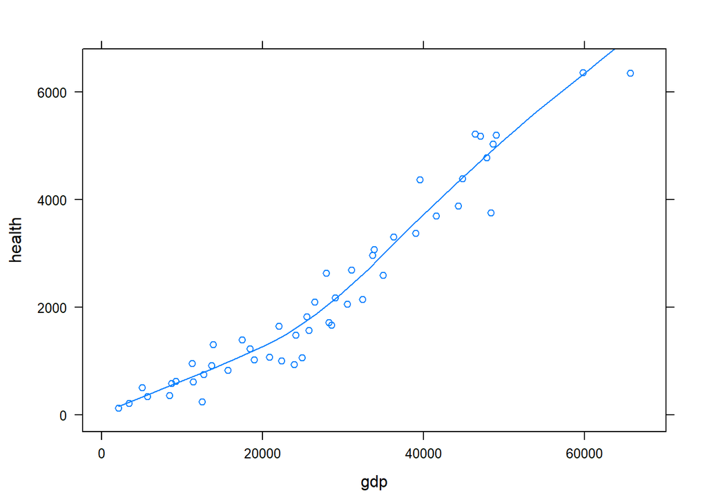

```r
library(lattice)
xyplot(health ~ gdp, data=y, type=c("p", "smooth"))
```

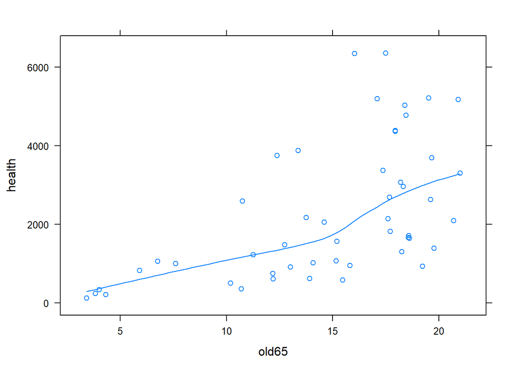

```r
xyplot(health ~ old65, data=y, type=c("p", "smooth"))
```

#2) Estimate a linear model where health expenditure depends on gdp and old65, present the results in a nice stargazer-type table.

```r
model <- lm(health~gdp+old65, data=y)
summary(model)
```

```
##
## Call:
## lm(formula = health ~ gdp + old65, data = y)
##
## Residuals:
##      Min       1Q   Median       3Q      Max
## -1031.15  -319.49     5.99   302.94   874.74
##
## Coefficients:
##               Estimate Std. Error t value Pr(>|t|)
## (Intercept) -8.561e+02  2.200e+02  -3.892 0.000312 ***
## gdp          1.053e-01  5.439e-03  19.352  < 2e-16 ***
## old65        1.618e+01  1.704e+01   0.950 0.347156
## ---
## Signif. codes:  0 '***' 0.001 '**' 0.01 '*' 0.05 '.' 0.1 ' ' 1
##
## Residual standard error: 484.1 on 47 degrees of freedom
## Multiple R-squared:  0.9242, Adjusted R-squared:  0.921
## F-statistic: 286.5 on 2 and 47 DF,  p-value: < 2.2e-16
```

```r
library(stargazer)
stargazer(model, type="text",
          dep.var.labels=c("Health expenditure"))
```

```
##
## ===============================================
##                         Dependent variable:
##                     ---------------------------
##                         Health expenditure
## -----------------------------------------------
## gdp                          0.105***
##                               (0.005)
##
## old65                         16.184
##                              (17.042)
##
## Constant                    -856.137***
##                              (219.978)
##
## -----------------------------------------------
## Observations                    50
## R2                             0.924
## Adjusted R2                    0.921
## Residual Std. Error      484.062 (df = 47)
## F Statistic           286.473*** (df = 2; 47)
## ===============================================
## Note:               *p<0.1; **p<0.05; ***p<0.01
```

#3) Interpret quantitatively the effects of explanatory variables

#4) Explain if both of the explanatory variables are individually statistically significant using t-test

#H0: beta=0 #H1: beta is not equal to 0 #If p > 0.05, we fail to reject H0 so that beta is zero at 5% significance level; and vice versa #In our model for gdp p-value = 2e-16, it is smaller than 0.05, therefore we reject our null hypothesis #t = 19.352 is highly significant p-value is small #for old65 p-value = 0.347156 We fail to reject null hypothesis of no relationship

#5) Test and explain if the explanatory variables are jointly statistically significant using F-test

```r
#restricted model
model_r<-lm(formula=health ~ 1, data=y)
summary(model_r)
```

```
##
## Call:
## lm(formula = health ~ 1, data = y)
##
## Residuals:
##    Min     1Q Median     3Q    Max
##  -2144  -1325   -576   1088   4096
##
## Coefficients:
##             Estimate Std. Error t value Pr(>|t|)
## (Intercept)   2269.2      243.5   9.319 1.98e-12 ***
## ---
## Signif. codes:  0 '***' 0.001 '**' 0.01 '*' 0.05 '.' 0.1 ' ' 1
##
## Residual standard error: 1722 on 49 degrees of freedom
```

```r
#Unrestricted model
model_ur<-lm(formula=health~gdp+old65, data=y)
summary(model_ur)
```

```
##
## Call:
## lm(formula = health ~ gdp + old65, data = y)
##
## Residuals:
##      Min       1Q   Median       3Q      Max
## -1031.15  -319.49     5.99   302.94   874.74
##
## Coefficients:
##               Estimate Std. Error t value Pr(>|t|)
## (Intercept) -8.561e+02  2.200e+02  -3.892 0.000312 ***
## gdp          1.053e-01  5.439e-03  19.352  < 2e-16 ***
## old65        1.618e+01  1.704e+01   0.950 0.347156
## ---
## Signif. codes:  0 '***' 0.001 '**' 0.01 '*' 0.05 '.' 0.1 ' ' 1
##
## Residual standard error: 484.1 on 47 degrees of freedom
## Multiple R-squared:  0.9242, Adjusted R-squared:  0.921
## F-statistic: 286.5 on 2 and 47 DF,  p-value: < 2.2e-16
```

```r
anova(model_r,model_ur)
```

```
## Analysis of Variance Table
##
## Model 1: health ~ 1
## Model 2: health ~ gdp + old65
##   Res.Df       RSS Df Sum of Sq      F    Pr(>F)
## 1     49 145263010
## 2     47  11012843  2 134250167 286.47 < 2.2e-16 ***
## ---
## Signif. codes:  0 '***' 0.001 '**' 0.01 '*' 0.05 '.' 0.1 ' ' 1
```

#We put our hypothesis like that #H0: Restricted model is fine #H1: We reject restricted model #as a result of anova test p value = 2.2e-16(too small) if p-value > 0.05 we fail to reject NH, but because p-value < 0.05, we reject null hypothesis.

#6) Test graphically and using Breusch-Pagan test if heteroskedasticity is present. Present the test results and write your conclusion. # If there is heteroskedasticity present, use robust standard errors and present your model jointly with the model from point (2) in a stargazer tabel.

```r
library(lmtest)
model <- lm(health~gdp+old65, data=y)
bptest(model)
```

```
##
##  studentized Breusch-Pagan test
##
## data:  model
## BP = 0.91048, df = 2, p-value = 0.6343
```

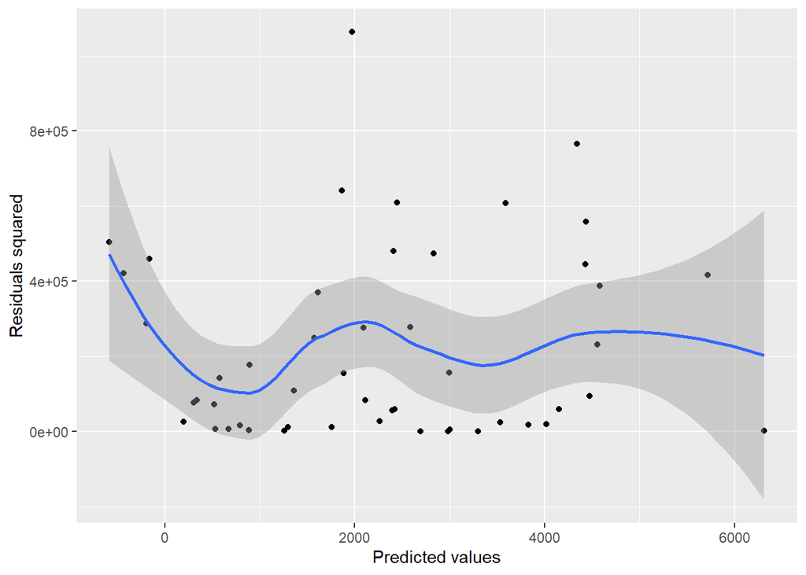

```r
y$yhat <- model$fitted.values
y$uhat <- model$residuals

#Lets do graphical tests
#Are squared residuals related to predicted values?
library(ggplot2)
require(ggplot2)
ggplot(y, aes(x=yhat, y=uhat^2)) +
  geom_point()+
  labs(x="Predicted values", y="Residuals squared") +
  geom_smooth()
```

#In order to test heteroskedasticity let`s do hypothesis #H0: homoskedasticity #H1: heteroskedasticity

#If p > 0.05 we fail to reject null hypothesis or vice versa #From BP test we get p-value more than 0.05 as a result we fail to reject NH. #We can conclude from the results that this model is homoskedastic.

#7)Test if the functional form is correct using RESET test (use powers 2 and 3). #Present the test results and write your conclusion.

```r
library(lmtest)
require(lmtest)
summary(model)
```

```
##
## Call:
## lm(formula = health ~ gdp + old65, data = y)
##
## Residuals:
##      Min       1Q   Median       3Q      Max
## -1031.15  -319.49     5.99   302.94   874.74
##
## Coefficients:
##               Estimate Std. Error t value Pr(>|t|)
## (Intercept) -8.561e+02  2.200e+02  -3.892 0.000312 ***
## gdp          1.053e-01  5.439e-03  19.352  < 2e-16 ***
## old65        1.618e+01  1.704e+01   0.950 0.347156
## ---
## Signif. codes:  0 '***' 0.001 '**' 0.01 '*' 0.05 '.' 0.1 ' ' 1
##
## Residual standard error: 484.1 on 47 degrees of freedom
## Multiple R-squared:  0.9242, Adjusted R-squared:  0.921
## F-statistic: 286.5 on 2 and 47 DF,  p-value: < 2.2e-16
```

```r
resettest(model, power=2:3, type = c("fitted"))
```

```
##
##  RESET test
##
## data:  model
## RESET = 33.045, df1 = 2, df2 = 45, p-value = 1.478e-09
```

#H0: The model is linear #H1: The model is not linear #If p-value > 0.05 we fail to reject NH. #As p-value = 1.478e-09 is very small value and definetely less than 0.05 that We reject our Null Hypothesis. # Our model is not linear.

8. Is there any outlier countries in the data that might influence your results? If yes, briefly mention that.

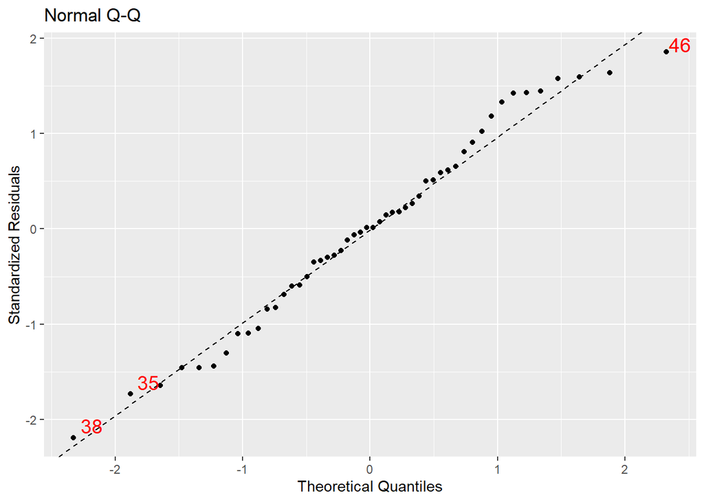

```r
library(mosaic)
mplot(model, which=2)
```

#As from the graph we can see that there are 3 outliers(countries) at both ends.

```r
modelnew<-lm(log(health)~log(gdp)+old65, data=y)
summary(modelnew)
```

```
##
## Call:
## lm(formula = log(health) ~ log(gdp) + old65, data = y)
##
## Residuals:
##      Min       1Q   Median       3Q      Max
## -0.85270 -0.12914  0.04785  0.17079  0.56623
##
## Coefficients:
##             Estimate Std. Error t value Pr(>|t|)
## (Intercept) -3.46003    0.59263  -5.838 4.72e-07 ***
## log(gdp)     1.02697    0.06810  15.081  < 2e-16 ***
## old65        0.03788    0.01043   3.633 0.000691 ***
## ---
## Signif. codes:  0 '***' 0.001 '**' 0.01 '*' 0.05 '.' 0.1 ' ' 1
##
## Residual standard error: 0.2677 on 47 degrees of freedom
## Multiple R-squared:  0.9219, Adjusted R-squared:  0.9185
## F-statistic: 277.3 on 2 and 47 DF,  p-value: < 2.2e-16
```

```r
library(stargazer)

stargazer(model, modelnew, type="text",
          dep.var.labels=c("Health expenditure"))
```

```
##
## ============================================================
##                                    Dependent variable:
##                               ------------------------------
##                               Health expenditure log(health)
##                                      (1)             (2)
## ------------------------------------------------------------
## gdp                                0.105***
##                                    (0.005)
##
## log(gdp)                                          1.027***
##                                                    (0.068)
##
## old65                               16.184        0.038***
##                                    (17.042)        (0.010)
##
## Constant                         -856.137***      -3.460***
##                                   (219.978)        (0.593)
##
## ------------------------------------------------------------
## Observations                          50             50
## R2                                  0.924           0.922
## Adjusted R2                         0.921           0.919
## Residual Std. Error (df = 47)      484.062          0.268
## F Statistic (df = 2; 47)          286.473***     277.265***
## ============================================================
## Note:                            *p<0.1; **p<0.05; ***p<0.01
```